# 05_analyses

Lena Kuschel

02 November 2020

## Analyses

### Library

```r
library(formr)
library(effects)
library(effectsize)
#library(lme4)
library(sjstats)
library(lmerTest)
library(dplyr)
```

```r
library(ggplot2)
library(RColorBrewer)
```

### Data

Load selected data based on 03_codebook

```r
data_included_documented = read.csv(file = "data_included_documented.csv")[,-1]
```

### Analysis

If the model does not converge, we will first exclude the random slope for country. If the model does still not converge, we will subsequently exclude the random intercept for country. Instead we will z-standardize outcomes separately for each country.

#### Preferred Relationship Options

##### H1a Interest in Single Life

H1a There is a negative linear link between right-wing political orientation and women’s interest in being single.  
Outcome: Ratings for interest in single life. Predictor: Political Orientation. Random intercept and random slope for country.

###### Models

```r
#model_interest_single <- lmer(interest_single ~ political_orientation + (1+political_orientation|country), data = data_included_documented)

#drop random slope as model did not converge:
model_interest_single <- lmer(interest_single ~ political_orientation + (1|country), data = data_included_documented)
```

###### Summary

```r
summary(model_interest_single)
```

```
## Linear mixed model fit by REML. t-tests use Satterthwaite's method [
## lmerModLmerTest]
## Formula: interest_single ~ political_orientation + (1 | country)
##    Data: data_included_documented
##
## REML criterion at convergence: 51984.7
##
## Scaled residuals:
##      Min       1Q   Median       3Q      Max
## -1.78770 -0.97549  0.00191  0.66544  2.74999
##
## Random effects:
##  Groups   Name        Variance Std.Dev.
##  country  (Intercept) 0.1265   0.3556
##  Residual             2.9743   1.7246
## Number of obs: 13208, groups:  country, 144
##
## Fixed effects:
##                         Estimate Std. Error         df t value Pr(>|t|)
## (Intercept)            2.483e+00  5.975e-02  1.519e+02  41.557  < 2e-16 ***
## political_orientation -7.216e-02  1.119e-02  1.320e+04  -6.451 1.15e-10 ***
## ---
## Signif. codes:  0 '***' 0.001 '**' 0.01 '*' 0.05 '.' 0.1 ' ' 1
##
## Correlation of Fixed Effects:
##             (Intr)
## pltcl_rnttn -0.487
```

```r
confint(model_interest_single, level = 0.997)
```

```
## Computing profile confidence intervals ...
```

```
##                           0.15 %    99.85 %
## .sig01                 0.2484172  0.5077128
## .sigma                 1.6934446  1.7565839
## (Intercept)            2.3029781  2.6614561
## political_orientation -0.1053516 -0.0389435
```

###### Standardized Coefficients

```r
standardize_parameters(model_interest_single, method = "basic", ci = 0.997)
```

```
## Parameter             | Coefficient (std.) |      1e+02% CI
## -----------------------------------------------------------
## (Intercept)           |               0.00 | [ 0.00,  0.00]
## political_orientation |              -0.06 | [-0.08, -0.03]
##
## # Standardization method: Basic
```

```r
#ci(standardize_parameters(model_interest_single, method = "basic"), ci = 0.997)
```

###### Plot

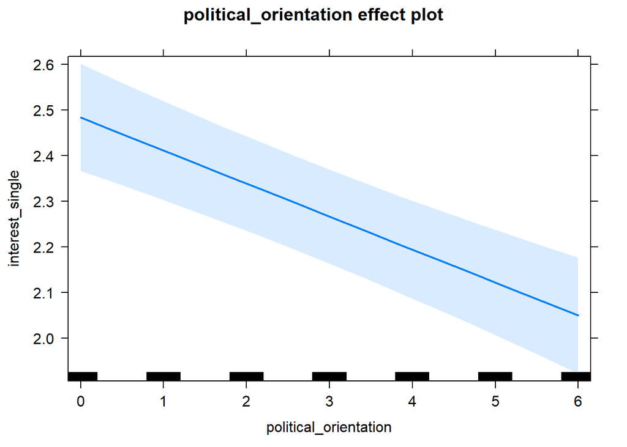

```r
lmer(interest_single ~ political_orientation + (1 | country),
       data = data_included_documented) %>%
    allEffects() %>%
    plot()
```

##### H1b Interest in sexual, non-romantic relationships

H1b There is a negative linear link between right-wing political orientation and women’s interest in having sexual, non-romantic relationships (e.g., hookups, one-night stands). Outcome: Ratings for interest in having sexual, non-romantic relationships. Predictor: Political Orientation. Random intercept and random slope for country.

###### Models

```r
model_interest_sexrel <- lmer(interest_sexrel ~ political_orientation + (1+political_orientation|country), data = data_included_documented)
```

###### Summary

```r
summary(model_interest_sexrel)
```

```
## Linear mixed model fit by REML. t-tests use Satterthwaite's method [
## lmerModLmerTest]
## Formula:
## interest_sexrel ~ political_orientation + (1 + political_orientation |
##     country)
##    Data: data_included_documented
##
## REML criterion at convergence: 53602.9
##
## Scaled residuals:
##     Min      1Q  Median      3Q     Max
## -3.2693 -0.8320 -0.0270  0.6843  2.4833
##
## Random effects:
##  Groups   Name                  Variance Std.Dev. Corr
##  country  (Intercept)           0.641077 0.80067
##           political_orientation 0.009858 0.09929  -0.48
##  Residual                       3.351582 1.83073
## Number of obs: 13193, groups:  country, 144
##
## Fixed effects:
##                       Estimate Std. Error       df t value Pr(>|t|)
## (Intercept)            2.55439    0.10742 75.86592  23.779   <2e-16 ***
## political_orientation  0.03063    0.02317 26.08455   1.322    0.198
## ---
## Signif. codes:  0 '***' 0.001 '**' 0.01 '*' 0.05 '.' 0.1 ' ' 1
##
## Correlation of Fixed Effects:
##             (Intr)
## pltcl_rnttn -0.623
```

```r
confint(model_interest_sexrel, level = 0.997)
```

```
## Computing profile confidence intervals ...
```

```
##                            0.15 %   99.85 %
## .sig01                 0.57735571 1.1169925
## .sig02                -0.80515842 0.2044050
## .sig03                 0.04046776 0.1989580
## .sigma                 1.79763320 1.8648773
## (Intercept)            2.23198230 2.8821107
## political_orientation -0.04332292 0.1027192
```

###### Standardized Coefficients

```r
standardize_parameters(model_interest_sexrel, method = "basic", ci = 0.997)
```

```
## Parameter             | Coefficient (std.) |     1e+02% CI
## ----------------------------------------------------------
## (Intercept)           |               0.00 | [ 0.00, 0.00]
## political_orientation |               0.02 | [-0.03, 0.07]
##
## # Standardization method: Basic
```

```r
#ci(standardize_parameters(model_interest_sexrel, method = "basic"), ci = 0.997)
```

###### Plot

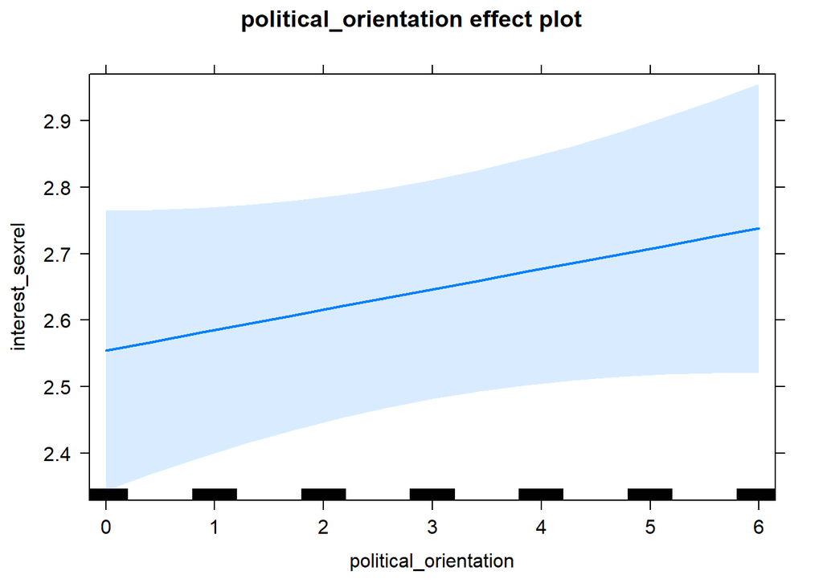

```r
lmer(interest_sexrel ~ political_orientation + (1 + political_orientation| country),
       data = data_included_documented) %>%
    allEffects() %>%
    plot()
```

##### H1c Interest in non-monogamous relationships

H1c There is a negative linear link between right-wing political orientation and women’s interest in having non-monogamous relationships. Outcome: Ratings for interest in having non-monogamous relationships. Predictor: Political Orientation. Random intercept and random slope for country.

###### Models

```r
model_interest_nonmonrel <- lmer(interest_nonmonrel ~ political_orientation + (1+political_orientation|country), data = data_included_documented)
```

###### Summary

```r
summary(model_interest_nonmonrel)
```

```
## Linear mixed model fit by REML. t-tests use Satterthwaite's method [
## lmerModLmerTest]
## Formula:
## interest_nonmonrel ~ political_orientation + (1 + political_orientation |
##     country)
##    Data: data_included_documented
##
## REML criterion at convergence: 47773.7
##
## Scaled residuals:
##     Min      1Q  Median      3Q     Max
## -1.0976 -0.6005 -0.4736  0.1977  3.8254
##
## Random effects:
##  Groups   Name                  Variance Std.Dev. Corr
##  country  (Intercept)           0.044813 0.2117
##           political_orientation 0.002883 0.0537   -0.28
##  Residual                       2.201891 1.4839
## Number of obs: 13145, groups:  country, 144
##
## Fixed effects:
##                       Estimate Std. Error       df t value Pr(>|t|)
## (Intercept)            1.08424    0.04896 28.80588  22.144  < 2e-16 ***
## political_orientation -0.06308    0.01510 21.06594  -4.177 0.000423 ***
## ---
## Signif. codes:  0 '***' 0.001 '**' 0.01 '*' 0.05 '.' 0.1 ' ' 1
##
## Correlation of Fixed Effects:
##             (Intr)
## pltcl_rnttn -0.674
```

```r
confint(model_interest_nonmonrel, level = 0.997)
```

```
## Computing profile confidence intervals ...
```

```
##                             0.15 %     99.85 %
## .sig01                 0.097360073  0.39771347
## .sig02                -0.845957912  1.00000000
## .sig03                 0.007861223  0.12103599
## .sigma                 1.457050029  1.51155111
## (Intercept)            0.924564194  1.23351057
## political_orientation -0.110911435 -0.01373634
```

###### Standardized Coefficients

```r
standardize_parameters(model_interest_nonmonrel, method = "basic", ci = 0.997)
```

```
## Parameter             | Coefficient (std.) |      1e+02% CI
## -----------------------------------------------------------
## (Intercept)           |               0.00 | [ 0.00,  0.00]
## political_orientation |              -0.06 | [-0.10, -0.02]
##
## # Standardization method: Basic
```

```r
#ci(standardize_parameters(model_interest_nonmonrel, method = "basic"), ci = 0.997)
```

###### Plot

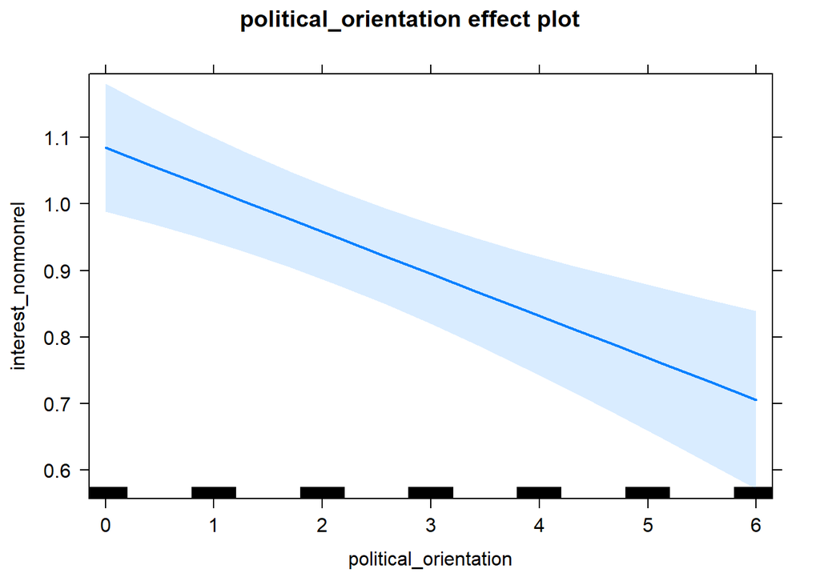

```r
lmer(interest_nonmonrel ~ political_orientation + (1+political_orientation|country),
       data = data_included_documented) %>%
    allEffects() %>%
    plot()
```

##### H1d Interest in monogamous relationships

H1d There is no link between right-wing political orientation and women’s interest in having monogamous relationships. Outcome: Ratings for interest in having monogamous relationships. Predictor: Political Orientation. Random intercept and random slope for country.

###### Models

```r
model_interest_monrel <- lmer(interest_monrel ~ political_orientation + (1+political_orientation|country), data = data_included_documented)
```

###### Summary

```r
summary(model_interest_monrel)
```

```
## Linear mixed model fit by REML. t-tests use Satterthwaite's method [
## lmerModLmerTest]
## Formula:
## interest_monrel ~ political_orientation + (1 + political_orientation |
##     country)
##    Data: data_included_documented
##
## REML criterion at convergence: 51466.6
##
## Scaled residuals:
##     Min      1Q  Median      3Q     Max
## -3.1170 -0.3423  0.4949  0.5938  1.5790
##
## Random effects:
##  Groups   Name                  Variance Std.Dev. Corr
##  country  (Intercept)           0.223799 0.47307
##           political_orientation 0.005481 0.07404  -0.48
##  Residual                       2.888030 1.69942
## Number of obs: 13165, groups:  country, 144
##
## Fixed effects:
##                       Estimate Std. Error       df t value Pr(>|t|)
## (Intercept)            4.86220    0.07775 38.45107   62.54   <2e-16 ***
## political_orientation  0.01367    0.01926 19.57901    0.71    0.486
## ---
## Signif. codes:  0 '***' 0.001 '**' 0.01 '*' 0.05 '.' 0.1 ' ' 1
##
## Correlation of Fixed Effects:
##             (Intr)
## pltcl_rnttn -0.673
```

```r
confint(model_interest_monrel, level = 0.997)
```

```
## Computing profile confidence intervals ...
```

```
##                            0.15 %    99.85 %
## .sig01                 0.29048103 0.75671836
## .sig02                -0.85871468 0.70228132
## .sig03                 0.01624831 0.16289424
## .sigma                 1.66869831 1.73115731
## (Intercept)            4.61102854 5.09881964
## political_orientation -0.04433665 0.08225734
```

###### Standardized Coefficients

```r
standardize_parameters(model_interest_monrel, method = "basic", ci = 0.997)
```

```
## Parameter             | Coefficient (std.) |     1e+02% CI
## ----------------------------------------------------------
## (Intercept)           |               0.00 | [ 0.00, 0.00]
## political_orientation |               0.01 | [-0.03, 0.05]
##
## # Standardization method: Basic
```

```r
ci(standardize_parameters(model_interest_monrel, method = "basic"), ci = 0.997) #calculate by hand to get exact numbers
```

```
##               Parameter   CI      CI_low    CI_high
## 1           (Intercept) 99.7  0.00000000 0.00000000
## 2 political_orientation 99.7 -0.03364193 0.05477878
```

###### Plot

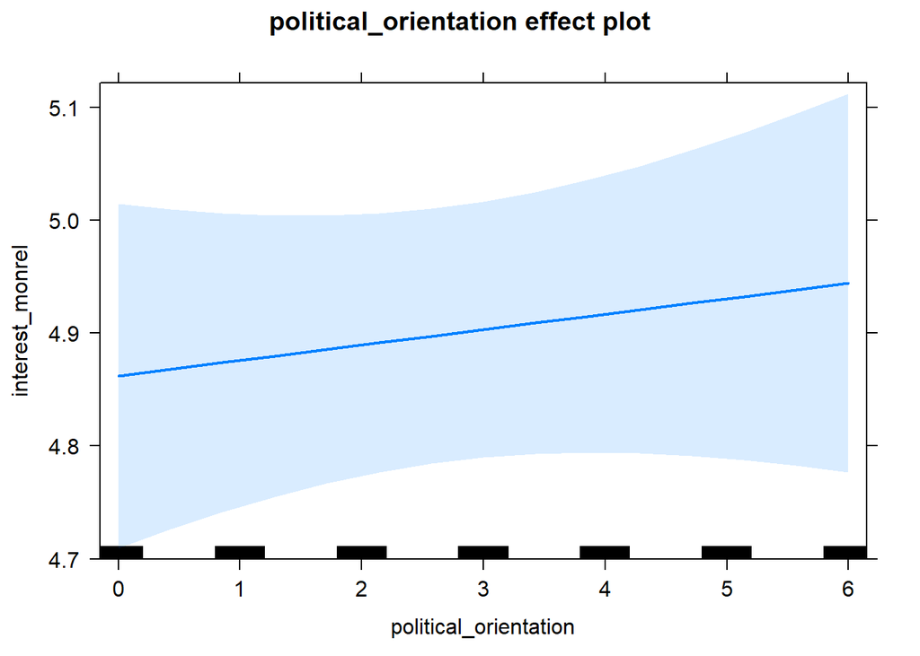

```r
lmer(interest_monrel ~ political_orientation + (1+political_orientation|country),
       data = data_included_documented) %>%
    allEffects() %>%
    plot()
```

#### Political, ethnic and religious similarity

##### H2a Preference for similarity in political beliefs

H2a There is no linear link between right-wing political orientation and women’s preferences for partner’s similar political beliefs and values when controlling for a quadratic link. There is a positive quadratic link between right-wing political orientation and women’s preferences for partner’s similar political beliefs and values when controlling for a linear link. Outcome: Preference ratings for partner’s similar political beliefs and values. Predictor: Political Orientation. Random intercept and random slope for country.

###### Models

```r
model_pref_politicalsim = lmer(pref_politicalsim ~ political_orientation + I(political_orientation^2) +
                                 (1+political_orientation|country),
                               data = data_included_documented)
```

###### Summary

```r
summary(model_pref_politicalsim)
```

```
## Linear mixed model fit by REML. t-tests use Satterthwaite's method [
## lmerModLmerTest]
## Formula:
## pref_politicalsim ~ political_orientation + I(political_orientation^2) +
##     (1 + political_orientation | country)
##    Data: data_included_documented
##
## REML criterion at convergence: 52259.3
##
## Scaled residuals:
##     Min      1Q  Median      3Q     Max
## -2.6987 -0.6613  0.1574  0.7454  2.1952
##
## Random effects:
##  Groups   Name                  Variance Std.Dev. Corr
##  country  (Intercept)           0.51941  0.7207
##           political_orientation 0.01527  0.1236   -0.72
##  Residual                       3.26631  1.8073
## Number of obs: 12949, groups:  country, 144
##
## Fixed effects:
##                              Estimate Std. Error         df t value Pr(>|t|)
## (Intercept)                 3.971e+00  1.093e-01  6.684e+01   36.32   <2e-16
## political_orientation      -6.575e-01  4.088e-02  1.722e+02  -16.08   <2e-16
## I(political_orientation^2)  1.098e-01  6.211e-03  1.097e+04   17.68   <2e-16
##
## (Intercept)                ***
## political_orientation      ***
## I(political_orientation^2) ***
## ---
## Signif. codes:  0 '***' 0.001 '**' 0.01 '*' 0.05 '.' 0.1 ' ' 1
##
## Correlation of Fixed Effects:
##             (Intr) pltcl_
## pltcl_rnttn -0.671
## I(pltcl_^2)  0.272 -0.779
```

```r
confint(model_pref_politicalsim, level = 0.997)
```

```
## Computing profile confidence intervals ...
```

```
##                                 0.15 %     99.85 %
## .sig01                      0.46451124  1.06851504
## .sig02                     -0.93290890 -0.09015427
## .sig03                      0.05157647  0.22873234
## .sigma                      1.77424992  1.84131768
## (Intercept)                 3.61937870  4.30180381
## political_orientation      -0.78145171 -0.52682213
## I(political_orientation^2)  0.09134806  0.12846396
```

###### Standardized Coefficients

```r
standardize_parameters(model_pref_politicalsim, method = "refit", ci = 0.997)
```

```
## Parameter                  | Coefficient (std.) |      1e+02% CI
## ----------------------------------------------------------------
## (Intercept)                |              -0.11 | [-0.22,  0.00]
## political_orientation      |              -0.07 | [-0.13, -0.02]
## I(political_orientation^2) |               0.11 | [ 0.09,  0.12]
##
## # Standardization method: Refit
```

```r
#ci(standardize_parameters(model_pref_politicalsim, method = "refit"), ci = 0.997)
```

###### Plot

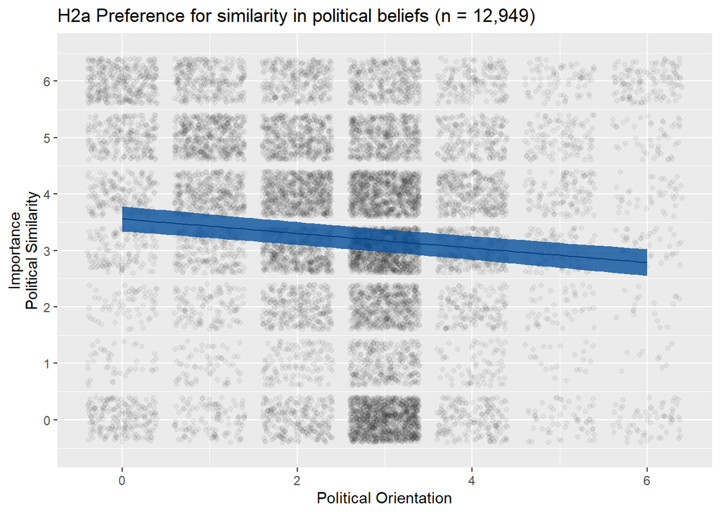

```r
effects1 = lmer(pref_politicalsim ~ political_orientation + (1 | country),
             data = data_included_documented) %>%
  allEffects(confidence.level = 0.997, xlevels = 49) %>%
  as.data.frame()

effects1 = as.data.frame(effects1$political_orientation)

n = data_included_documented %>%
  filter(!is.na(pref_politicalsim)) %>%
  count()

plot1 = ggplot() +
  geom_jitter(data = data_included_documented, aes(x = political_orientation, y = pref_politicalsim),
              alpha = 0.05) +
  geom_line(data = effects1, aes(x = political_orientation, y = fit)) +
  geom_ribbon(data = effects1, aes(x = political_orientation, ymin = lower, ymax = upper),
              fill = brewer.pal(9,"Blues")[8], alpha = 0.8) +
  scale_x_continuous(name = "Political Orientation") +
  scale_y_continuous(name = "Importance\nPolitical Similarity",
                     limits = c(-0.5,6.5),
                     breaks = c(0,1,2,3,4,5,6)) +
  ggtitle(paste0(
      "H2a Preference for similarity in political beliefs (n = ",
      prettyNum(n$n, big.mark = ",", preserve.width = "none"),
      ")"))
plot1
```

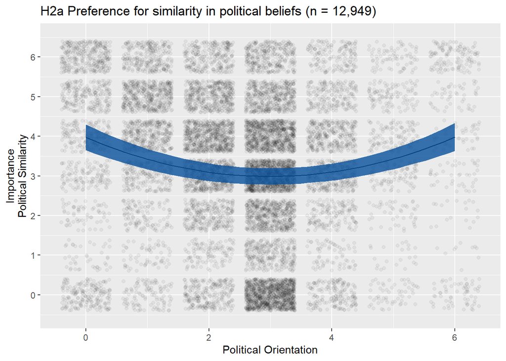

```r
effects2 = lmer(pref_politicalsim ~ political_orientation + I(political_orientation^2) +
                  (1 + political_orientation | country),
             data = data_included_documented) %>%
  allEffects(confidence.level = 0.997, xlevels = 49) %>%
  as.data.frame()

effects2 = as.data.frame(effects2$political_orientation)

n = data_included_documented %>%
  filter(!is.na(pref_politicalsim)) %>%
  count()

plot2 = ggplot() +
  geom_jitter(data = data_included_documented, aes(x = political_orientation,
                                                   y = pref_politicalsim), alpha = 0.05) +
  geom_line(data = effects2, aes(x = political_orientation, y = fit)) +
  geom_ribbon(data = effects2, aes(x = political_orientation, ymin = lower, ymax = upper),
              fill = brewer.pal(9,"Blues")[8], alpha = 0.8) +
  scale_x_continuous(name = "Political Orientation") +
  scale_y_continuous(name = "Importance\nPolitical Similarity",
                     limits = c(-0.5,6.5),
                     breaks = c(0,1,2,3,4,5,6)) +
  ggtitle(paste0(
      "H2a Preference for similarity in political beliefs (n = ",
      prettyNum(n$n, big.mark = ",", preserve.width = "none"),
      ")"))
plot2
```

##### H2b Preference for similarity in ethnicity/race

H2b There is a positive linear link between right-wing political orientation and women’s preferences for partner’s similar ethnicity/race. Outcome: Preference ratings for partner’s similar ethnicity/race. Predictor: Political Orientation. Random intercept and random slope for country.

###### Models

```r
model_pref_ethnicalsim <- lmer(pref_ethnicalsim ~ political_orientation + (1+political_orientation|country), data = data_included_documented)
```

###### Summary

```r
summary(model_pref_ethnicalsim)
```

```
## Linear mixed model fit by REML. t-tests use Satterthwaite's method [
## lmerModLmerTest]
## Formula:
## pref_ethnicalsim ~ political_orientation + (1 + political_orientation |
##     country)
##    Data: data_included_documented
##
## REML criterion at convergence: 30431.4
##
## Scaled residuals:
##     Min      1Q  Median      3Q     Max
## -3.2873 -0.4577 -0.0320  0.5952  2.4044
##
## Random effects:
##  Groups   Name                  Variance Std.Dev. Corr
##  country  (Intercept)           0.083554 0.28906
##           political_orientation 0.006436 0.08022  -0.40
##  Residual                       1.955964 1.39856
## Number of obs: 8643, groups:  country, 127
##
## Fixed effects:
##                       Estimate Std. Error       df t value Pr(>|t|)
## (Intercept)            2.93634    0.06570 24.05963  44.694  < 2e-16 ***
## political_orientation  0.14098    0.02046 25.39390   6.889 2.94e-07 ***
## ---
## Signif. codes:  0 '***' 0.001 '**' 0.01 '*' 0.05 '.' 0.1 ' ' 1
##
## Correlation of Fixed Effects:
##             (Intr)
## pltcl_rnttn -0.728
```

```r
confint(model_pref_ethnicalsim, level = 0.997)
```

```
## Computing profile confidence intervals ...
```

```
##                            0.15 %   99.85 %
## .sig01                 0.11069564 0.5654954
## .sig02                -0.87971426 0.7726430
## .sig03                 0.03014792 0.1653162
## .sigma                 1.36741251 1.4309525
## (Intercept)            2.73858107 3.1632222
## political_orientation  0.07038154 0.2025605
```

###### Standardized Coefficients

```r
standardize_parameters(model_pref_ethnicalsim, method = "basic", ci = 0.997)
```

```
## Parameter             | Coefficient (std.) |    1e+02% CI
## ---------------------------------------------------------
## (Intercept)           |               0.00 | [0.00, 0.00]
## political_orientation |               0.13 | [0.07, 0.18]
##
## # Standardization method: Basic
```

```r
#ci(standardize_parameters(model_pref_ethnicalsim, method = "basic"), ci = 0.997)
```

###### Plot

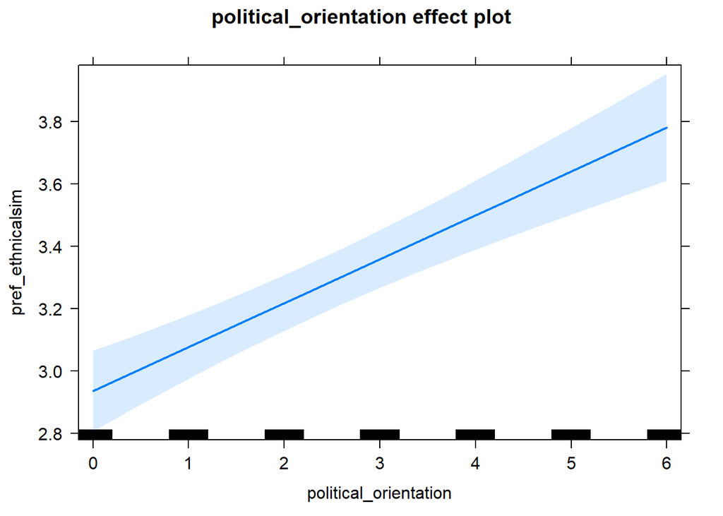

```r
lmer(pref_ethnicalsim ~ political_orientation + (1+political_orientation|country),
       data = data_included_documented) %>%
    allEffects() %>%
    plot()
```

##### H2c Preference for similarity in religion

H2c There is a positive linear link between right-wing political orientation and women’s preferences for partner’s similar religious beliefs.  
Outcome: Preference ratings for partner’s similar religious beliefs. Predictor: Political Orientation. Random intercept and random slope for country.

###### Models

```r
model_pref_religioussim <- lmer(pref_religioussim ~ political_orientation + (1+political_orientation|country), data = data_included_documented)
```

###### Summary

```r
summary(model_pref_religioussim)
```

```
## Linear mixed model fit by REML. t-tests use Satterthwaite's method [
## lmerModLmerTest]
## Formula:
## pref_religioussim ~ political_orientation + (1 + political_orientation |
##     country)
##    Data: data_included_documented
##
## REML criterion at convergence: 56523.3
##
## Scaled residuals:
##     Min      1Q  Median      3Q     Max
## -2.1900 -1.0116  0.0650  0.8719  1.9319
##
## Random effects:
##  Groups   Name                  Variance Std.Dev. Corr
##  country  (Intercept)           0.388999 0.62370
##           political_orientation 0.004839 0.06956  -0.29
##  Residual                       4.571227 2.13804
## Number of obs: 12937, groups:  country, 144
##
## Fixed effects:
##                       Estimate Std. Error       df t value Pr(>|t|)
## (Intercept)            2.95120    0.09640 31.33198  30.614  < 2e-16 ***
## political_orientation  0.17408    0.02132 23.38866   8.166 2.66e-08 ***
## ---
## Signif. codes:  0 '***' 0.001 '**' 0.01 '*' 0.05 '.' 0.1 ' ' 1
##
## Correlation of Fixed Effects:
##             (Intr)
## pltcl_rnttn -0.575
```

```r
confint(model_pref_religioussim, level = 0.997)
```

```
## Computing profile confidence intervals ...
```

```
##                             0.15 %   99.85 %
## .sig01                 0.327418380 1.0217927
## .sig02                -0.907171880 1.0000000
## .sig03                 0.004598001 0.1587623
## .sigma                 2.099015572 2.1783470
## (Intercept)            2.637243786 3.3410490
## political_orientation  0.073780282 0.2632057
```

###### Standardized Coefficients

```r
standardize_parameters(model_pref_religioussim, method = "basic", ci = 0.997)
```

```
## Parameter             | Coefficient (std.) |    1e+02% CI
## ---------------------------------------------------------
## (Intercept)           |               0.00 | [0.00, 0.00]
## political_orientation |               0.11 | [0.07, 0.15]
##
## # Standardization method: Basic
```

```r
#ci(standardize_parameters(model_pref_religioussim, method = "basic"), ci = 0.997)
```

###### Plot

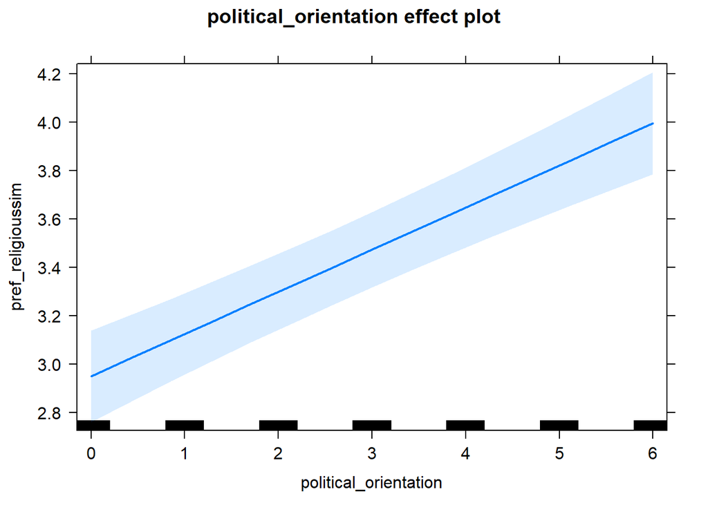

```r
lmer(pref_religioussim ~ political_orientation + (1+political_orientation|country),
       data = data_included_documented) %>%
    allEffects() %>%
    plot()
```

#### Ideal Partner Preferences

##### H3a Preference for the level of financial security- successfulness

H3a There is a positive linear link between right-wing political orientation and women’s preferences for the level of financial security and successfulness. Outcome: Level ratings for partner’s financial security-successfulness. Predictor: Political Orientation. Random intercept and random slope for country.

###### Models

```r
#model_pref_level_financially_secure_successful_ambitious <- lmer(pref_level_financially_secure_successful_ambitious ~ political_orientation + (1+political_orientation|country), data = data_included_documented)

#drop random slope as model did not converge
model_pref_level_financially_secure_successful_ambitious <- lmer(pref_level_financially_secure_successful_ambitious ~ political_orientation + (1|country), data = data_included_documented)
```

###### Summary

```r
summary(model_pref_level_financially_secure_successful_ambitious)
```

```
## Linear mixed model fit by REML. t-tests use Satterthwaite's method [
## lmerModLmerTest]
## Formula:
## pref_level_financially_secure_successful_ambitious ~ political_orientation +
##     (1 | country)
##    Data: data_included_documented
##
## REML criterion at convergence: 31734.9
##
## Scaled residuals:
##     Min      1Q  Median      3Q     Max
## -4.8226 -0.7112 -0.0059  0.6774  2.4896
##
## Random effects:
##  Groups   Name        Variance Std.Dev.
##  country  (Intercept) 0.08139  0.2853
##  Residual             0.72469  0.8513
## Number of obs: 12551, groups:  country, 143
##
## Fixed effects:
##                        Estimate Std. Error        df t value Pr(>|t|)
## (Intercept)           4.311e+00  3.851e-02 1.130e+02  111.95   <2e-16 ***
## political_orientation 8.714e-02  5.722e-03 1.254e+04   15.23   <2e-16 ***
## ---
## Signif. codes:  0 '***' 0.001 '**' 0.01 '*' 0.05 '.' 0.1 ' ' 1
##
## Correlation of Fixed Effects:
##             (Intr)
## pltcl_rnttn -0.386
```

```r
confint(model_pref_level_financially_secure_successful_ambitious, level = 0.997)
```

```
## Computing profile confidence intervals ...
```

```
##                           0.15 %   99.85 %
## .sig01                0.20075524 0.4008334
## .sigma                0.83549130 0.8675320
## (Intercept)           4.19707184 4.4335097
## political_orientation 0.07016661 0.1041397
```

###### Standardized Coefficients

```r
standardize_parameters(model_pref_level_financially_secure_successful_ambitious, method = "basic", ci = 0.997)
```

```
## Parameter             | Coefficient (std.) |    1e+02% CI
## ---------------------------------------------------------
## (Intercept)           |               0.00 | [0.00, 0.00]
## political_orientation |               0.13 | [0.11, 0.16]
##
## # Standardization method: Basic
```

```r
#ci(standardize_parameters(model_pref_level_financially_secure_successful_ambitious, method = "basic"), ci = 0.997)
```

###### Plot

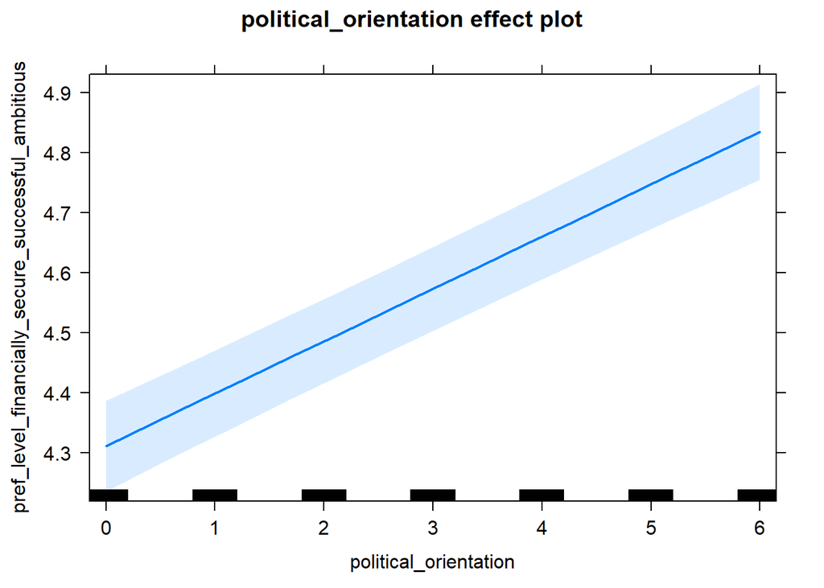

```r
lmer(pref_level_financially_secure_successful_ambitious ~ political_orientation + (1|country),
       data = data_included_documented) %>%
    allEffects() %>%
    plot()
```

##### H3b Preference for the level of kindness-supportiveness

H3b There is no link between right-wing political orientation and women’s preferences for the level of kindness and supportiveness.  
Outcome: Level ratings for partner’s kindness-supportiveness. Predictor: Political Orientation. Random intercept and random slope for country.

###### Models

```r
#model_pref_level_kind_supportive <- lmer(pref_level_kind_supportive ~ political_orientation + (1+political_orientation|country), data = data_included_documented)

model_pref_level_kind_supportive <- lmer(pref_level_kind_supportive ~ political_orientation + (1|country), data = data_included_documented)
```

###### Summary

```r
summary(model_pref_level_kind_supportive)
```

```
## Linear mixed model fit by REML. t-tests use Satterthwaite's method [
## lmerModLmerTest]
## Formula: pref_level_kind_supportive ~ political_orientation + (1 | country)
##    Data: data_included_documented
##
## REML criterion at convergence: 26551.3
##
## Scaled residuals:
##     Min      1Q  Median      3Q     Max
## -4.7898 -0.6747  0.0713  0.8026  1.7591
##
## Random effects:
##  Groups   Name        Variance Std.Dev.
##  country  (Intercept) 0.01992  0.1412
##  Residual             0.46748  0.6837
## Number of obs: 12729, groups:  country, 143
##
## Fixed effects:
##                        Estimate Std. Error        df t value Pr(>|t|)
## (Intercept)           5.167e+00  2.398e-02 1.412e+02 215.494   <2e-16 ***
## political_orientation 1.001e-02  4.535e-03 1.272e+04   2.207   0.0274 *
## ---
## Signif. codes:  0 '***' 0.001 '**' 0.01 '*' 0.05 '.' 0.1 ' ' 1
##
## Correlation of Fixed Effects:
##             (Intr)
## pltcl_rnttn -0.492
```

```r
confint(model_pref_level_kind_supportive, level = 0.997)
```

```
## Computing profile confidence intervals ...
```

```
##                            0.15 %    99.85 %
## .sig01                 0.09676518 0.20459980
## .sigma                 0.67113985 0.69664455
## (Intercept)            5.09551688 5.24108995
## political_orientation -0.00344907 0.02347343
```

###### Standardized Coefficients

```r
standardize_parameters(model_pref_level_kind_supportive, method = "basic", ci = 0.997)
```

```
## Parameter             | Coefficient (std.) |     1e+02% CI
## ----------------------------------------------------------
## (Intercept)           |               0.00 | [ 0.00, 0.00]
## political_orientation |               0.02 | [-0.01, 0.05]
##
## # Standardization method: Basic
```

```r
ci(standardize_parameters(model_pref_level_kind_supportive, method = "basic"), ci = 0.997)
```

```
##               Parameter   CI       CI_low    CI_high
## 1           (Intercept) 99.7  0.000000000 0.00000000
## 2 political_orientation 99.7 -0.006715211 0.04563091
```

```r
#calculate by hand to get exact numbers
```

###### Plot

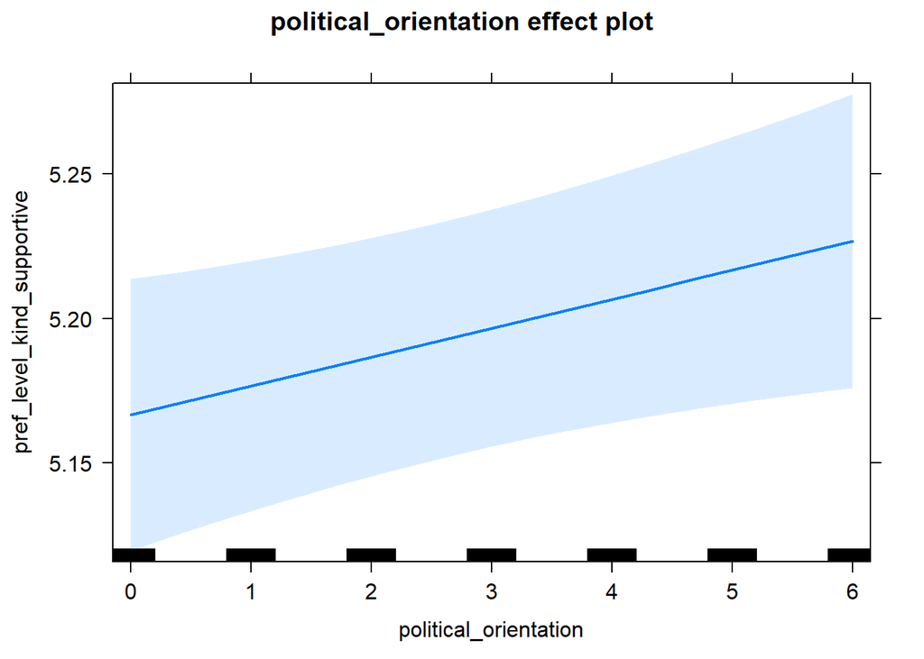

```r
lmer(pref_level_kind_supportive ~ political_orientation + (1|country),
       data = data_included_documented) %>%
    allEffects() %>%
    plot()
```

##### H3c Preference for the level of attractiveness

H3c There is no link between right-wing political orientation and women’s preferences for the level of attractiveness.  
Outcome: Level ratings for partner’s attractiveness. Predictor: Political Orientation. Random intercept and random slope for country.

###### Models

```r
#model_pref_level_attractiveness <- lmer(pref_level_attractiveness ~ political_orientation + (1+political_orientation|country), data = data_included_documented)

#Model failed to converge, drop random slope:
model_pref_level_attractiveness <- lmer(pref_level_attractiveness ~ political_orientation + (1|country), data = data_included_documented)
```

###### Summary

```r
summary(model_pref_level_attractiveness)
```

```
## Linear mixed model fit by REML. t-tests use Satterthwaite's method [
## lmerModLmerTest]
## Formula: pref_level_attractiveness ~ political_orientation + (1 | country)
##    Data: data_included_documented
##
## REML criterion at convergence: 32922
##
## Scaled residuals:
##     Min      1Q  Median      3Q     Max
## -4.6385 -0.6488 -0.0224  0.6486  2.5585
##
## Random effects:
##  Groups   Name        Variance Std.Dev.
##  country  (Intercept) 0.01528  0.1236
##  Residual             0.80614  0.8979
## Number of obs: 12526, groups:  country, 142
##
## Fixed effects:
##                        Estimate Std. Error        df t value Pr(>|t|)
## (Intercept)           3.923e+00  2.665e-02 1.586e+02 147.206   <2e-16 ***
## political_orientation 4.107e-02  6.029e-03 1.246e+04   6.813    1e-11 ***
## ---
## Signif. codes:  0 '***' 0.001 '**' 0.01 '*' 0.05 '.' 0.1 ' ' 1
##
## Correlation of Fixed Effects:
##             (Intr)
## pltcl_rnttn -0.587
```

```r
confint(model_pref_level_attractiveness, level = 0.997)
```

```
## Computing profile confidence intervals ...
```

```
##                           0.15 %    99.85 %
## .sig01                0.08053203 0.19002532
## .sigma                0.88120369 0.91493873
## (Intercept)           3.84336890 4.00321277
## political_orientation 0.02315061 0.05895783
```

###### Standardized Coefficients

```r
standardize_parameters(model_pref_level_attractiveness, method = "basic", ci = 0.997)
```

```
## Parameter             | Coefficient (std.) |    1e+02% CI
## ---------------------------------------------------------
## (Intercept)           |               0.00 | [0.00, 0.00]
## political_orientation |               0.06 | [0.03, 0.09]
##
## # Standardization method: Basic
```

```r
#ci(standardize_parameters(model_pref_level_attractiveness, method = "basic"), ci = 0.997)
```

###### Plot

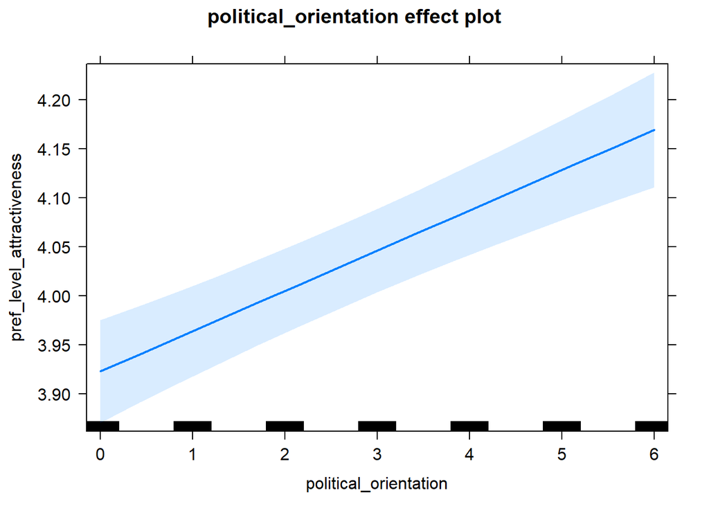

```r
lmer(pref_level_attractiveness ~ political_orientation + (1|country),
       data = data_included_documented) %>%
    allEffects() %>%
    plot()
```

##### H3d Preference for the level of confidence-assertiveness

H3d There is a positive linear link between right-wing political orientation and women’s preferences for the level of confidence and assertiveness.  
Outcome: Level ratings for partner’s confidence-assertiveness. Predictor: Political Orientation. Random intercept and random slope for country.

###### Models

```r
model_pref_level_confident_assertive <- lmer(pref_level_confident_assertive ~ political_orientation + (1+political_orientation|country), data = data_included_documented)
```

###### Summary

```r
summary(model_pref_level_confident_assertive)
```

```
## Linear mixed model fit by REML. t-tests use Satterthwaite's method [
## lmerModLmerTest]
## Formula: pref_level_confident_assertive ~ political_orientation + (1 +
##     political_orientation | country)
##    Data: data_included_documented
##
## REML criterion at convergence: 28928.4
##
## Scaled residuals:
##     Min      1Q  Median      3Q     Max
## -5.4786 -0.6797 -0.0354  0.6526  3.0002
##
## Random effects:
##  Groups   Name                  Variance  Std.Dev. Corr
##  country  (Intercept)           0.1517929 0.38961
##           political_orientation 0.0007536 0.02745  -0.52
##  Residual                       0.5614582 0.74931
## Number of obs: 12697, groups:  country, 144
##
## Fixed effects:
##                        Estimate Std. Error        df t value Pr(>|t|)
## (Intercept)           4.432e+00  4.713e-02 1.022e+02  94.046  < 2e-16 ***
## political_orientation 2.946e-02  7.797e-03 2.186e+01   3.778  0.00104 **
## ---
## Signif. codes:  0 '***' 0.001 '**' 0.01 '*' 0.05 '.' 0.1 ' ' 1
##
## Correlation of Fixed Effects:
##             (Intr)
## pltcl_rnttn -0.544
```

```r
confint(model_pref_level_confident_assertive, level = 0.997)
```

```
## Computing profile confidence intervals ...
```

[output not shown]

[output cut: 202 more lines]

[output not shown]

```
##                             0.15 %    99.85 %
## .sig01                 0.288701169 0.52594297
## .sig02                -1.000000000 0.23927669
## .sig03                 0.003555668 0.05946359
## .sigma                 0.735494368 0.76355617
## (Intercept)            4.291019619 4.57603976
## political_orientation  0.003430270 0.05344236
```

###### Standardized Coefficients

```r
standardize_parameters(model_pref_level_confident_assertive, method = "basic", ci = 0.997)
```

```
## Parameter             | Coefficient (std.) |    1e+02% CI
## ---------------------------------------------------------
## (Intercept)           |               0.00 | [0.00, 0.00]
## political_orientation |               0.05 | [0.01, 0.08]
##
## # Standardization method: Basic
```

```r
#ci(standardize_parameters(model_pref_level_confident_assertive, method = "basic"), ci = 0.997)
```

###### Plot

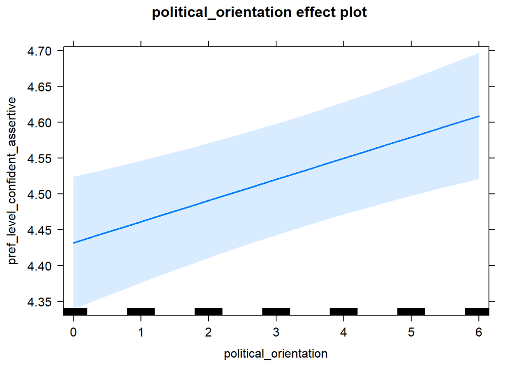

```r
lmer(pref_level_confident_assertive ~ political_orientation + (1+political_orientation|country),
       data = data_included_documented) %>%
    allEffects() %>%
    plot()
```

##### H3e Preference for the level of education-intelligence

H3e There is no link between right-wing political orientation and women’s preferences for the level of education and intelligence.  
Outcome: Level ratings for partner’s education-intelligence. Predictor: Political Orientation. Random intercept and random slope for country.

###### Models

```r
#model_pref_level_intelligence_educated <- lmer(pref_level_intelligence_educated ~ political_orientation + (1+political_orientation|country), data = data_included_documented)

#Model failed to converge, drop random slope:
model_pref_level_intelligence_educated <- lmer(pref_level_intelligence_educated ~ political_orientation + (1|country), data = data_included_documented)
```

###### Summary

```r
summary(model_pref_level_intelligence_educated)
```

```
## Linear mixed model fit by REML. t-tests use Satterthwaite's method [
## lmerModLmerTest]
## Formula: pref_level_intelligence_educated ~ political_orientation + (1 |
##     country)
##    Data: data_included_documented
##
## REML criterion at convergence: 30148.6
##
## Scaled residuals:
##     Min      1Q  Median      3Q     Max
## -5.2719 -0.6833  0.0335  0.6874  2.1594
##
## Random effects:
##  Groups   Name        Variance Std.Dev.
##  country  (Intercept) 0.06091  0.2468
##  Residual             0.61873  0.7866
## Number of obs: 12723, groups:  country, 141
##
## Fixed effects:
##                        Estimate Std. Error        df t value Pr(>|t|)
## (Intercept)           4.821e+00  3.428e-02 1.461e+02 140.622   <2e-16 ***
## political_orientation 1.422e-02  5.232e-03 1.272e+04   2.717   0.0066 **
## ---
## Signif. codes:  0 '***' 0.001 '**' 0.01 '*' 0.05 '.' 0.1 ' ' 1
##
## Correlation of Fixed Effects:
##             (Intr)
## pltcl_rnttn -0.397
```

```r
confint(model_pref_level_intelligence_educated, level = 0.997)
```

```
## Computing profile confidence intervals ...
```

```
##                             0.15 %    99.85 %
## .sig01                 0.181153546 0.33678809
## .sigma                 0.772103859 0.80147154
## (Intercept)            4.718791389 4.92572600
## political_orientation -0.001309603 0.02976188
```

###### Standardized Coefficients

```r
standardize_parameters(model_pref_level_intelligence_educated, method = "basic", ci = 0.997)
```

```
## Parameter             | Coefficient (std.) |     1e+02% CI
## ----------------------------------------------------------
## (Intercept)           |               0.00 | [ 0.00, 0.00]
## political_orientation |               0.02 | [ 0.00, 0.05]
##
## # Standardization method: Basic
```

```r
ci(standardize_parameters(model_pref_level_intelligence_educated, method = "basic"), ci = 0.997)
```

```
##               Parameter   CI       CI_low   CI_high
## 1           (Intercept) 99.7  0.000000000 0.0000000
## 2 political_orientation 99.7 -0.002179216 0.0492906
```

```r
#calculate by hand to get exact numbers
```

###### Plot

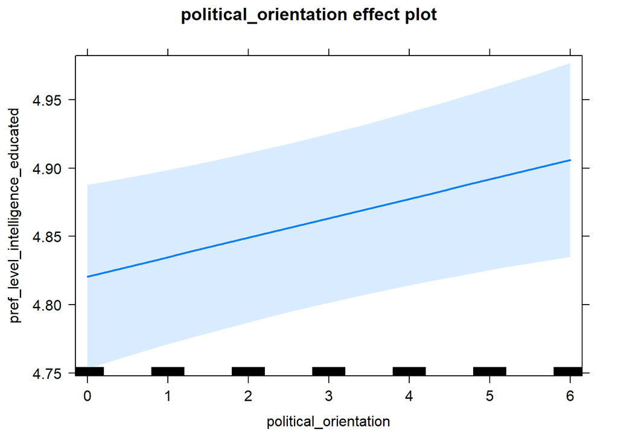

```r
lmer(pref_level_intelligence_educated ~ political_orientation + (1|country),
       data = data_included_documented) %>%
    allEffects() %>%
    plot()
```

#### Ideal age and height

##### H4a(1) Importance Ratings for partner’s age

H4a(1) There is a positive linear link between right-wing political orientation and women’s importance ratings for partner’s age. Outcome: Importance ratings for partner’s age. Predictor: Political Orientation. Random intercept and random slope for country.

###### Models

```r
model_imp_age <- lmer(imp_age ~ political_orientation + (1+political_orientation|country), data = data_included_documented)
```

###### Summary

```r
summary(model_imp_age)
```

```
## Linear mixed model fit by REML. t-tests use Satterthwaite's method [
## lmerModLmerTest]
## Formula: imp_age ~ political_orientation + (1 + political_orientation |
##     country)
##    Data: data_included_documented
##
## REML criterion at convergence: 46141.4
##
## Scaled residuals:
##     Min      1Q  Median      3Q     Max
## -3.0525 -0.5057  0.1715  0.6392  2.1583
##
## Random effects:
##  Groups   Name                  Variance Std.Dev. Corr
##  country  (Intercept)           0.08559  0.2926
##           political_orientation 0.01024  0.1012   -0.76
##  Residual                       1.95847  1.3995
## Number of obs: 13113, groups:  country, 143
##
## Fixed effects:
##                       Estimate Std. Error       df t value Pr(>|t|)
## (Intercept)            3.50975    0.05990 21.71787  58.598  < 2e-16 ***
## political_orientation  0.08199    0.02057 15.91198   3.985  0.00108 **
## ---
## Signif. codes:  0 '***' 0.001 '**' 0.01 '*' 0.05 '.' 0.1 ' ' 1
##
## Correlation of Fixed Effects:
##             (Intr)
## pltcl_rnttn -0.832
```

```r
confint(model_imp_age, level= 0.997)
```

```
## Computing profile confidence intervals ...
```

```
##                            0.15 %   99.85 %
## .sig01                 0.10866823 0.5631709
## .sig02                -0.96038292 0.6426776
## .sig03                 0.01169286 0.2058255
## .sigma                 1.37411875 1.4257678
## (Intercept)            3.32012969 3.7190380
## political_orientation  0.01339876 0.1510101
```

###### Standardized Coefficients

```r
standardize_parameters(model_imp_age, method = "basic", ci = 0.997)
```

```
## Parameter             | Coefficient (std.) |    1e+02% CI
## ---------------------------------------------------------
## (Intercept)           |               0.00 | [0.00, 0.00]
## political_orientation |               0.08 | [0.02, 0.14]
##
## # Standardization method: Basic
```

```r
#ci(standardize_parameters(model_imp_age, method = "basic"), ci = 0.997)
```

###### Plot

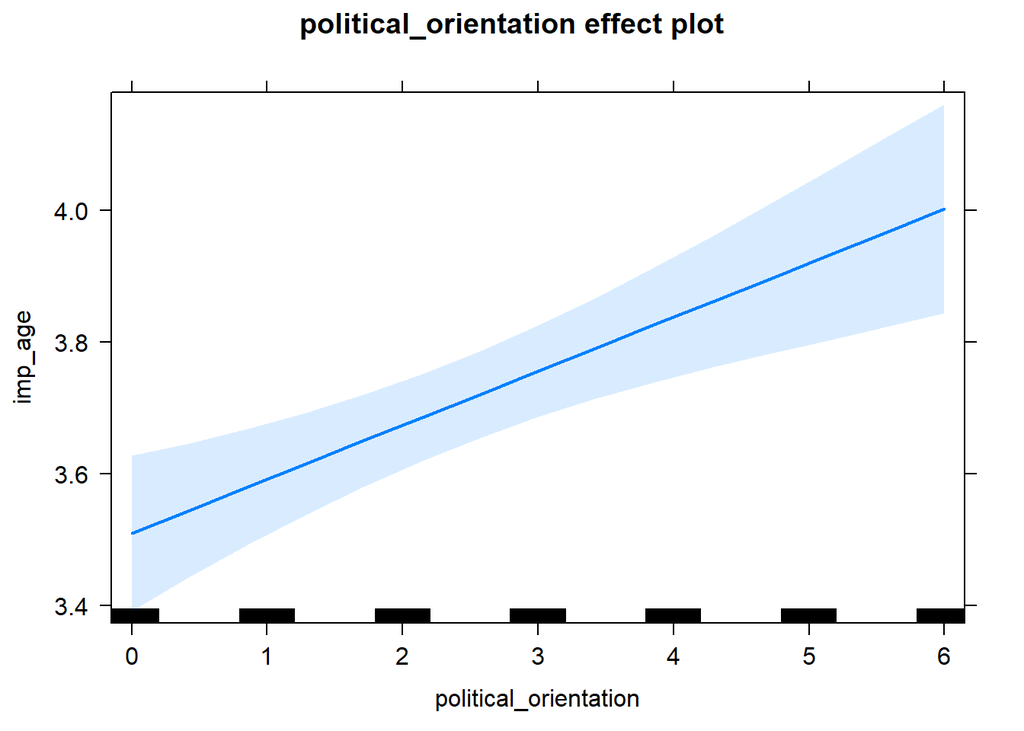

```r
lmer(imp_age ~ political_orientation + (1+political_orientation|country),
       data = data_included_documented) %>%
    allEffects() %>%
    plot()
```

##### H4a(2)Level Ratings for partner’s age

H4a(2) There is a positive linear link between right-wing political orientation and the relative age discrepancy between ideal partner’s age and women’s age. (discrepancy calculated as ideal partner’s age – women’s age) Outcome: Discrepancy between level ratings for ideal partner’s age and women’s age (ideal_age_rel) Predictor: Political Orientation. Random intercept and random slope for country.

###### Models

```r
#model_ideal_age_rel <- lmer(ideal_age_rel ~ political_orientation + (1+political_orientation|country), data = data_included_documented)

#Model failed to converge, drop random slope:
model_ideal_age_rel <- lmer(ideal_age_rel ~ political_orientation + (1|country), data = data_included_documented)
```

###### Summary

```r
summary(model_ideal_age_rel)
```

```
## Linear mixed model fit by REML. t-tests use Satterthwaite's method [
## lmerModLmerTest]
## Formula: ideal_age_rel ~ political_orientation + (1 | country)
##    Data: data_included_documented
##
## REML criterion at convergence: 61754.5
##
## Scaled residuals:
##      Min       1Q   Median       3Q      Max
## -11.8131  -0.4556  -0.1045   0.4240  25.5911
##
## Random effects:
##  Groups   Name        Variance Std.Dev.
##  country  (Intercept) 1.102    1.050
##  Residual             9.693    3.113
## Number of obs: 12057, groups:  country, 140
##
## Fixed effects:
##                        Estimate Std. Error        df t value Pr(>|t|)
## (Intercept)           2.857e+00  1.425e-01 5.362e+01  20.052   <2e-16 ***
## political_orientation 1.819e-02  2.125e-02 1.203e+04   0.856    0.392
## ---
## Signif. codes:  0 '***' 0.001 '**' 0.01 '*' 0.05 '.' 0.1 ' ' 1
##
## Correlation of Fixed Effects:
##             (Intr)
## pltcl_rnttn -0.389
```

```r
confint(model_ideal_age_rel, level = 0.997)
```

```
## Computing profile confidence intervals ...
```

```
##                            0.15 %   99.85 %
## .sig01                 0.50835725 1.5999451
## .sigma                 3.05431268 3.1745339
## (Intercept)            2.43444013 3.3156376
## political_orientation -0.04484375 0.0813763
```

###### Standardized Coefficients

```r
standardize_parameters(model_ideal_age_rel, method = "basic", ci = 0.997)
```

```
## Parameter             | Coefficient (std.) |     1e+02% CI
## ----------------------------------------------------------
## (Intercept)           |               0.00 | [ 0.00, 0.00]
## political_orientation |           7.88e-03 | [-0.02, 0.04]
##
## # Standardization method: Basic
```

```r
#ci(standardize_parameters(model_ideal_age_rel, method = "basic"), ci = 0.997)
```

###### Plot

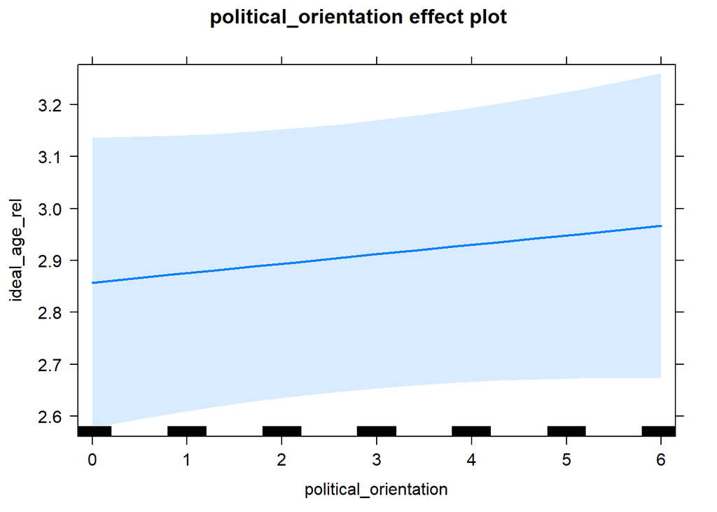

```r
lmer(ideal_age_rel ~ political_orientation + (1|country),
       data = data_included_documented) %>%
    allEffects() %>%
    plot()
```

##### H4b(1) Importance Ratings for partner’s height

H4b(1) There is a positive linear link between right-wing political orientation and women’s importance ratings for partner’s height. Outcome: Importance ratings for partner’s height. Predictor: Political Orientation. Random intercept and random slope for country.

###### Models

```r
#model_imp_height <- lmer(imp_height ~ political_orientation + (1+political_orientation|country), data = data_included_documented)

#drop random slope as model did not converge
model_imp_height <- lmer(imp_height ~ political_orientation + (1|country), data = data_included_documented)
```

###### Summary

```r
summary(model_imp_height)
```

```
## Linear mixed model fit by REML. t-tests use Satterthwaite's method [
## lmerModLmerTest]
## Formula: imp_height ~ political_orientation + (1 | country)
##    Data: data_included_documented
##
## REML criterion at convergence: 46916.1
##
## Scaled residuals:
##     Min      1Q  Median      3Q     Max
## -3.2944 -0.5540  0.1154  0.7258  2.0380
##
## Random effects:
##  Groups   Name        Variance Std.Dev.
##  country  (Intercept) 0.0746   0.2731
##  Residual             2.1307   1.4597
## Number of obs: 13026, groups:  country, 143
##
## Fixed effects:
##                        Estimate Std. Error        df t value Pr(>|t|)
## (Intercept)           3.766e+00  4.859e-02 1.398e+02   77.50   <2e-16 ***
## political_orientation 1.228e-01  9.547e-03 1.301e+04   12.87   <2e-16 ***
## ---
## Signif. codes:  0 '***' 0.001 '**' 0.01 '*' 0.05 '.' 0.1 ' ' 1
##
## Correlation of Fixed Effects:
##             (Intr)
## pltcl_rnttn -0.512
```

```r
confint(model_imp_height, level = 0.997)
```

```
## Computing profile confidence intervals ...
```

```
##                           0.15 %   99.85 %
## .sig01                0.18293926 0.4009084
## .sigma                1.43312120 1.4869371
## (Intercept)           3.62136530 3.9177025
## political_orientation 0.09451885 0.1512321
```

###### Standardized Coefficients

```r
standardize_parameters(model_imp_height, method = "basic", ci = 0.997)
```

```
## Parameter             | Coefficient (std.) |    1e+02% CI
## ---------------------------------------------------------
## (Intercept)           |               0.00 | [0.00, 0.00]
## political_orientation |               0.11 | [0.09, 0.14]
##
## # Standardization method: Basic
```

```r
#ci(standardize_parameters(model_imp_height, method = "basic"), ci = 0.997)
```

###### Plot

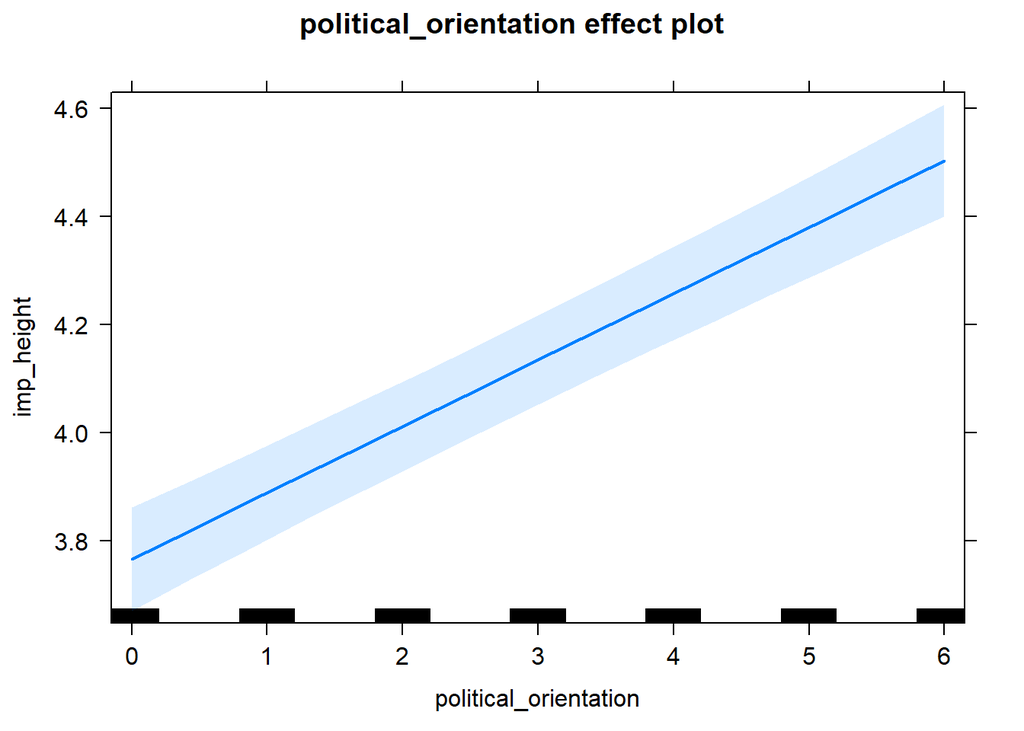

```r
lmer(imp_height ~ political_orientation + (1|country),
       data = data_included_documented) %>%
    allEffects() %>%
    plot()
```

##### H4b(2)Level Ratings for partner’s height

H4b(2) There is a positive linear link between right-wing political orientation and ideal partner’s height. Outcome: Level ratings for ideal partner’s height. Predictor: Political Orientation. Random intercept and random slope for country.

###### Models

```r
#model_ideal_height <- lmer(ideal_height ~ political_orientation + (1+political_orientation|country), data = data_included_documented)

#drop random slope as model did not converge
model_ideal_height <- lmer(ideal_height ~ political_orientation + (1|country), data = data_included_documented)
```

###### Summary

```r
summary(model_ideal_height)
```

```
## Linear mixed model fit by REML. t-tests use Satterthwaite's method [
## lmerModLmerTest]
## Formula: ideal_height ~ political_orientation + (1 | country)
##    Data: data_included_documented
##
## REML criterion at convergence: 14686.9
##
## Scaled residuals:
##     Min      1Q  Median      3Q     Max
## -7.0994 -0.1199 -0.0636 -0.0087  2.4920
##
## Random effects:
##  Groups   Name        Variance Std.Dev.
##  country  (Intercept) 0.002449 0.04949
##  Residual             0.188162 0.43378
## Number of obs: 12524, groups:  country, 142
##
## Fixed effects:
##                        Estimate Std. Error        df t value Pr(>|t|)
## (Intercept)           1.031e+00  1.200e-02 1.004e+02  85.930   <2e-16 ***
## political_orientation 2.316e-03  2.898e-03 1.232e+04   0.799    0.424
## ---
## Signif. codes:  0 '***' 0.001 '**' 0.01 '*' 0.05 '.' 0.1 ' ' 1
##
## Correlation of Fixed Effects:
##             (Intr)
## pltcl_rnttn -0.630
```

```r
confint(model_ideal_height, level = 0.997)
```

```
## Computing profile confidence intervals ...
```

```
##                             0.15 %    99.85 %
## .sig01                 0.025628105 0.08639218
## .sigma                 0.425734903 0.44204740
## (Intercept)            0.995605419 1.06823963
## political_orientation -0.006279455 0.01092274
```

###### Standardized Coefficients

```r
standardize_parameters(model_ideal_height, method = "basic", ci = 0.997)
```

```
## Parameter             | Coefficient (std.) |     1e+02% CI
## ----------------------------------------------------------
## (Intercept)           |               0.00 | [ 0.00, 0.00]
## political_orientation |           7.21e-03 | [-0.02, 0.03]
##
## # Standardization method: Basic
```

```r
#ci(standardize_parameters(model_ideal_height, method = "basic"), ci = 0.997)
```

###### Plot

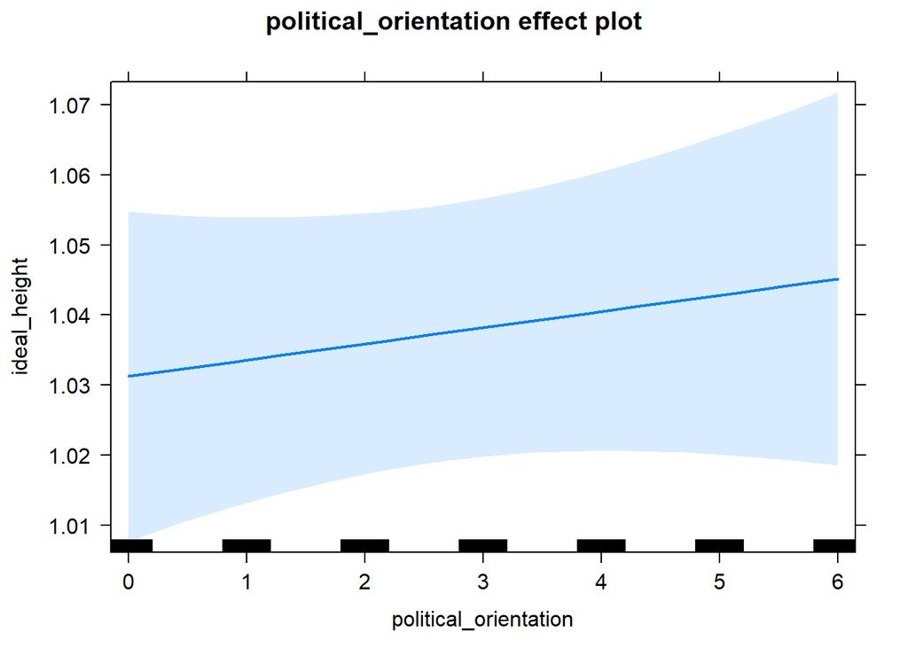

```r
lmer(ideal_height ~ political_orientation + (1|country),
       data = data_included_documented) %>%
    allEffects() %>%
    plot()
```